# Paleobotany and divergence time estimation using RevBayes

### 1.3. The constant fossilization rate

Once again, we are using a constant rate model; so we assume that the fossilization rate is constant through time and across lineages. We will use an empirical prior that centers the fossilization rate such that, on average, we expect to see the number of fossils that we observe in our empirical dataset:

```r
# empirical prior on the fossilization rate
fossilization_prior_mean <- num_fossils * diversification_prior_mean / (exp(diversification_prior_mean * origin_time) - 1)
fossilization_prior_sd   <- 2 * H
```

We then draw the fossilization rate $\Psi$ from the lognormal distribution of the prior. And add some moves on this parameter:

```r
# the fossilization rate
psi ~ dnLognormal( ln(fossilization_prior_mean) - fossilization_prior_sd * fossilization_prior_sd * 0.5, fossilization_prior_sd)

# add moves
moves.append( mvScale(psi, weight = 1.0) )
```

Now that we have defined all the elements for and FBD tree (starting time, and the speciation, extinction and fossilization rates) we can create our FBD distribution of trees `dnFBDP` from which we will sample our timetrees:

```r
# make the FBD tree

timetree ~ dnFBDP(
    originAge = origin_time,
    lambda = lambda,
    mu = mu,
    psi = psi,
    condition = "survival",
    taxa = taxa,
    rho = rho
)
```

As with any parameter that is being estimated, we need to set-up some moves on the tree. In fact, the tree topology is hard to estimate, so will place a lot of moves on it. Let’s start with the topology and branch lengths:

```r
# Proposals on the tree topology
moves.append( mvSubtreeScale(timetree, weight=ntax/5.0) )
moves.append( mvFNPR(timetree,                       weight = ntax                      ) )
moves.append( mvNarrow(timetree,                     weight = 5 * ntax                  ) )
moves.append( mvNodeTimeSlideUniform(timetree,       weight = 5 * ntax                  ) )
moves.append( mvSubtreeScale(timetree,               weight = 5 * ntax                  ) )
moves.append( mvRootTimeSlideUniform(timetree,       weight = ntax, origin = origin_time) )
```

Because in this model the fossils can be sampled ancestors, we will add some moves for this parameter and we will keep track of it (i.e. store that variable in the memory of our computer).

```r
# MCMC proposals on whether fossils are sampled ancestors
moves.append( mvCollapseExpandFossilBranch(timetree, weight = num_fossils, origin = origin_time) )
# keep track of number of sampled ancestors
num_sampled_ancestors := timetree.numSampledAncestors()
```

Next, we will add some moves on the age of the fossils to accomodate for stratigraphic uncertainty that we expressed in our initial `taxa.tsv`.

```r
# MCMC proposals on the fossil ages
fossils = timetree.getFossils()
for(i in 1:fossils.size()) {

  # get the fossil age
  t[i] := tmrca(timetree, clade(fossils[i]))

  # specify the age contraint
  a = fossils[i].getMinAge()
  b = fossils[i].getMaxAge()

  F[i] ~ dnUniform(t[i] - b, t[i] - a)
  F[i].clamp( 0 )

  # specify a proposal on the fossil age
  moves.append( mvFossilTimeSlideUniform(timetree, origin_time, fossils[i], weight = 1.0) )

}
```

And our last move is a joint move on the tree and the branch rates. Joint moves are useful when we have parameters that are correlated.

```r
# make a joint proposal for the tree (and later the branch rates)
moves.append( mvUpDownScale(weight=10, tuneTarget=0.234, lambda=0.01) )
tree_scale_move_index = moves.size()
moves[tree_scale_move_index].addVariable(timetree,    up=false)
moves[tree_scale_move_index].addVariable(origin_time, up=false)
```

Finally, we will keep track of the tree length (TL) throughout our analysis, so we will add it:

```r
# keep track of the tree length
TL := timetree.treeLength()
```

We are now done specifying our timetree model!

*Notes for your thoughts*: The **fossilization rate** is a variable that has probably been misnamed. Many paleontologists will argue that a better name for this rate would be **fossil recovery rate**. What do you think? Does this have implications for our modelling decisions?

## 2) The Molecular Evolution Model

Back to the main script, we will specify our **molecular evolution model** (i.e. **the way** in which molecular changes occur) with the next piece of code:

```r
source("scripts/mol_evol_model.Rev")
```

Because we have 3 molecular markers, and we need a Q-matrix (`mole_Q`) and the molecular site rates (`mole_site_rates`) for each of them, we will use a for loop in our code. Notice that we will also add some moves for each parameter inside the loop.

```r
# Q matrix per partition
  # for each alignment
for (i in 1:naln) {
  # the stationary frequency
  mole_pi[i] ~ dnDirichlet(rep(1,4))
  moves.append( mvBetaSimplex(mole_pi[i], weight = 1.0) )

  # the exchangeability rates
  mole_kappa[i] ~ dnDirichlet(rep(1,6))
  moves.append( mvBetaSimplex(mole_kappa[i], weight = 1.0))

  # create the Q matrices
  mole_Q[i] := fnGTR(mole_kappa[i], mole_pi[i])

  # the site rates drawn from a gamma distribution
  alpha[i] ~ dnExponential( 1.0 )
  moves.append( mvScale(alpha[i], lambda=0.01, weight=1.0) )
  moves.append( mvScale(alpha[i], lambda=0.1,  weight=1.0) )
  moves.append( mvScale(alpha[i], lambda=1,    weight=1.0) )
  mole_site_rates[i] := fnDiscretizeGamma( alpha[i], alpha[i], 4)
}
```

Next, we expect that the rates of molecular evolution vary between markers too! So, we will accommodate this by creating a rate multiplier (`mole_relative_rates`) that we will use later to scale the number of substitutions in each marker to the same tree branch.

```r
# we allow different markers evolve at different rates
# relative-rate multipliers
mole_proportional_rates ~ dnDirichlet(rep(1, naln))
moves.append( mvBetaSimplex(mole_proportional_rates, weight = naln) )

# rescale the rates so the mean is 1
mole_relative_rates := abs(mole_proportional_rates * naln)
```

I didn’t go into much detail about the molecular evolution model, but if you want to learn more, you can visit [this tutorial](https://revbayes.github.io/tutorials/ctmc/) for more information on the molecular evolution models, or [this tutorial](https://revbayes.github.io/tutorials/partition/) to learn more about why and how we partition molecular data.

*Notes for your thoughts*: As for all the components on the Bayesian TED model, you can choose between different models and way to parametrize. In practical terms, the molecular evolution parameters of a GTR + G model are often some of the easiest to estimate within this framework.

## 3) The Molecular Clock Model: relaxed Uncorrelated LogNormal

Back to the main script, we will specify our **molecular clock model** (i.e. the **rate at** which molecular changes occur) by sourcing the appropriate script:

```r
source("scripts/mol_clock_model.Rev")
```

Let’s walk through the code in the script `scripts/mol_clock_model.Rev`. The **molecular clock model** describes the rate at which sequences evolve along lineages. In this tutorial we will use an **Uncorrelated LogNormal (UCLN) clock model**. This model assumes that **each branch has its own rate**; that those rates are not correlated (as opposed to local clocks, where the rates are clade-dependent), and that the rates come from a LogNormal distribution.

Let’s start by defining that LogNormal distribution from which we will pick the branch rates. We need two parameters to define it: the mean (`mole_clock_rate_mean`) and the standard deviation (`mole_clock_rate_sd`). We will add moves for each:

```r
# draw the clock mean such as its log distribution is uniform
mole_clock_rate_mean ~ dnLoguniform(1e-10, 1e1)
moves.append( mvScale(mole_clock_rate_mean) )
mole_clock_rate_mean.setValue(1e-7)
# draw the standard deviation from an exponential
mole_clock_rate_sd ~ dnExponential(abs(1 / H))
moves.append( mvScale(mole_clock_rate_sd) )
```

And now, we can get the individual branch rates (`mole_branch_rates`) -and add some moves- using a for-loop. Notice that all the individual branch rates are drawn from the shared distribution we specified above:

```r
# the branch-specific rates
for(i in 1:nbranch) {
  # draw the log of the rate
  mole_branch_rates[i] ~ dnLognormal(
    ln(mole_clock_rate_mean) - mole_clock_rate_sd * mole_clock_rate_sd * 0.5, mole_clock_rate_sd)
  moves.append( mvScale(mole_branch_rates[i]) )
}
```

Let’s now calculate the mean of all the molecular branch rates. We will keep track of this value in the output of our analysis.

```r
# the mean of the branch rate
mole_branch_rate_mean := mean(mole_branch_rates)
```

Now, do you remember the joint move that we started setting up in the timetree model? Let’s finishing setting up the move so it simultaneously makes proposals on the tree -what we already did-, and on the branch rates -what we are doing here-. This move makes sense because we can expect that given a certain number of substitutions, as the substitution rates are higher (the changes happen in less amount of time), the timetree gets younger.

```r
# add branch rates to joint scale move on tree
moves[tree_scale_move_index].addVariable(mole_branch_rates, up=true)
moves[tree_scale_move_index].addVariable(mole_clock_rate_mean, up=true)
```

*Notes for your thoughts*: The clock models are a very important component of any dating analysis; they infer the **expected number of trait changes per unit of time** that allow us to scale the branch lengths expressed in **expected number of changes** (coming from the molecular evolution model) to the time we observe in the timetree. The parameters of the clock model (the branch rates) are often very expensive (in terms of computational power) to estimate, and are highly sensitive to our priors (particularly the one of the age of the root). You can learn more about molecular clocks [in this tutorial](https://revbayes.github.io/tutorials/clocks/).

### The CTMC for molecular data

Up to this point in the tutorial, we have fully **specified** our molecular model. This is, we have established the priors and the relationships among all the parameters that describe how molecular sequences evolve in the timetree.

We will now use the function `dnPhyloCTMC()` to create **a distribution of time calibrated trees** that simultaneously satisfy our `timetree` model, our molecular evolution model (`mole_Q`, `mole_site_rates`, and `mole_relative_rates`), and our molecular clock model (`mole_branch_rates`). We sample from this distribution of trees as we did for all our parameters (by using `~`). But instead of adding moves to estimate our parameter, we **feed our sequence data to the model** with the function `.clamp(data)`. In fact, it is only until this piece of code that we link our model, to our data!

As you can see below, we do this for each marker using a for-loop:

```r
# make the CTMC for molecular data
for(i in 1:naln) {
  seq[i] ~ dnPhyloCTMC(timetree, mole_Q[i], branchRates = mole_branch_rates, siteRates = mole_site_rates[i] * mole_relative_rates[i])
  seq[i].clamp( moledata[i] )
}
```

## 4) The Morphological Evolution Model

Now let’s switch gears and think about our **morphological evolution model**. As we did for the molecular data, we will now specify a model that describes **how** the morphological changes occur in our lineages.

It is worth to take a minute to discuss the fact that morphological characters are harder to model because they are not easy to generalize. For example, unlike molecular traits, different morphological characters may have a different number of character states; and it is unclear what the best partition scheme is. Accurately modelling morphological character evolution requires expertise in the group and it can be computationally expensive. The truth is that morphological evolution is an active and promising field of research. If you want to know more about it, you can start in [this tutorial](https://revbayes.github.io/tutorials/morph_tree/).

Back in the main script, we will run our **Mk morphological evolution model** by sourcing the script:

```r
source("scripts/morph_evol_model.Rev")
```

You can check the code for this component of the main Bayesain TED model by going to `scripts/morph_evol_model.Rev`.

Today, we will use **the Mk model** for our morphological traits. This model describes the change from one character to another using a matrix (similar to the Q-matrix), in a way that the we need a 2x2 matrix to model the evolution of a trait with 2 character states; a 3x3 matrix to model the evolution of trait with 3 states; and so on. That is the practical reason why we needed to partition our morphological matrix by number of character states.

Regardless of the number of states, the Mk model assumes that all the changes among character states have the **same probability**. It is an extension of the JC model of character evolution, and that is why the function we use is `fnJC`. once more, notice that we do this in a for-loop, so we have one `morph_Q` per partition of morphological data.

```r
# for each morphological partition
for (i in 1:num_morph_parts) {
    morph_Q[i] <- fnJC(nc[i])
}
```

We don’t expect that different characters evolve at the same rate. We will relax that assumption of the Mk-model, by adding a parameter multiplier picked from a discretized gamma distribution. This is analogous to the **+ Gamma** parameter of the molecular evolution model.

```r
# Specifying the gamma parameter
  # number of categories
num_rate_cats_morph = 4
  # prior
morph_site_rate_alpha ~ dnUniform(0, 10)
  # moves
moves.append( mvScale(morph_site_rate_alpha) )
  # site rates
morph_site_rates := fnDiscretizeGamma(morph_site_rate_alpha, morph_site_rate_alpha, num_rate_cats_morph)
```

*Notes for your thoughts*: What other particularities have morphological data-sets? Perhaps in the way we, biologists, collect the data. Yes! We tend to focus only on the characters that vary between terminals! I invite you to read about this **ascertainment bias** [here](https://revbayes.github.io/tutorials/morph_tree/#sec_ascertainment_bias).

## 5) The Morphological Clock Model

Back again the main script, we will specify our **morphological clock model** by sourcing the following script:

```r
source("scripts/morph_clock_model.Rev")
```

In that script, we will describe **the rate** at which morphological traits evolve along the lineages.

We will assume that the rates of morphological evolution are drawn from a common uniform distribution in the log scale. So we will set the prior and add some moves on it as follows:

```r
# draw the log of the rate from a uniform distribution
morph_clock_rate_log ~ dnUniform(-10, 1)
moves.append( mvSlide(morph_clock_rate_log) )
morph_clock_rate_log.setValue(-7)

# exponentiate
morph_clock_rate := exp(morph_clock_rate_log)
```

In this tutorial we will assume that the morphological clock and the molecular clock are **correlated**. This is, we will assume that a lineage whose sequences evolve faster, also has a morphology that evolves faster, comparatively to other lineages. The way we will parametrize this is by setting the individual morphological branch rates (`morph_branch_rates`) as a function of the molecular branch rates (`mole_branch_rates`).

```r
# the branch-specific morphological rates
morph_branch_rates := morph_clock_rate * mole_branch_rates / mole_branch_rate_mean
```

*Notes for your thoughts*: Do you think that molecular and morphological rates of change are correlated? How would you test it?

As we did for the molecular side of the model. We now have to specify our CTMC to feed our morphological data to our model. Back in the main script we will use a four loop to do this for each partition:

```r
# Make the CTMC for morphological data

for (i in 1:morph_Q.size()){
  morph[i] ~ dnPhyloCTMC(timetree, morph_Q[i], branchRates = morph_branch_rates, siteRates = morph_site_rates, coding  = "variable", type = "Standard")
  morph[i].clamp ( morph_partitions[i] )
}
```

Notice that this time we had to add the arguments `coding = "variable", type = "Standard"` so we communicate to RevBayes that this is categorical morphological data.

## Running the analysis

The last thing we need to do is to store our fully specified model, with its attached data, in an object called `my_model`.

```r
my_model = model(timetree)
```

Now we have **fully specified** our **Bayesian TED model** (yey!) we are ready to run our analysis. The code that follows *gives directions* to RevBayes about how to run our MCMC. For example, for how long (i.e. how many generations), how often and where to store the output, whether or not to print info in our computer screen as the analysis run.

Before starting to set these parameters, it is worth to mention that you can check [this tutorial](https://revbayes.github.io/tutorials/mcmc/binomial.html) if you need a refresher as to what an MCMC is and how it works.

From an empiricist point of view, you need to remember that an **MCMC** (Markov Chain Monte Carlo) uses an algorithm (the Metropolis Hastings algorithm) to **propose changes** (yes! this is where all those moves you set up come into play) on the parameters of a model. The **Metropolis Hastings algorithm** is set up so those proposed changes are **always accepted** when the proposed change increases the **Posterior Probability** of the parameter, and sometimes when it doesn’t. But the most important, is that the MCMC *visits* the parameter values **proportionally to their posterior probability (PP)**. So the values with higher PP will be visited **more often**. So when we visualize the density of the values that the MCMC visited (in Tracer for example), we can get an estimate of the parameter value and an error associated to it!!

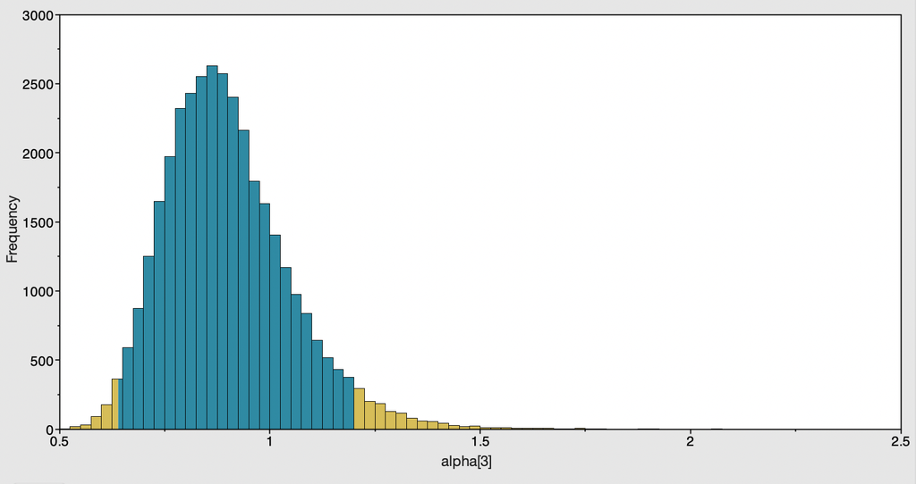

**Fig. 2.** Marginal density of a parameter

Now let’s start by specifying where we want to store the results of the analysis. The files will be saved in a directory called `output/run_1`. Having the extra folder (`run_1`) comes specially handy when you do multiple runs of one analysis. For example, maybe you are trying slightly different versions of one analysis that you want to compare later.

```r
# specifying the output directory
output_dir      = "output"
output_extra    = "run_1" # change the name as you wish
output_filename = output_dir + "/" + output_extra + "/"
```

The MCMC will run usually for thousands of generations. We can decide whether or not to store every single parameter value the MCMC visits. Here, we will store the values every 10 generations:

```r
# print generation every 10 iteration
printgen <- 10
```

We also need to set up monitors (i.e. things that the computer will keep track of). In practice, the MCMC can run without storing **any** of the states it visits. We need to tell it to print the states in the screen of our computer:

```r
monitors.append( mnScreen(printgen = printgen) )
```

In a file:

```r
monitors.append( mnModel(filename  = output_filename + "params.log", printgen = printgen, exclude = ["F"]) )
```

And we also want a separate file for the trees:

```r
monitors.append( mnFile(filename   = output_filename + "tree.trees", printgen = printgen, timetree) )
```

Next, we will tell the MCMC for how many generations it will run. One generation roughly corresponds to proposing one of the moves we defined. In this example we will run the MCMC for 20000 generations.

```r
ITERATIONS = 20000
```

RevBayes has the option of running a **burnin** chain. This chain optimizes the weight of the moves of the parameters. For example, it will increase the weight of the moves on parameters that are harder to estimate.

```r
BURNIN     = 1000
```

Next, we store all the information of our MCMC analysis in one object called `my_mcmc`. Notice that the arguments are the mode, the monitors, and the moves.

```r
my_mcmc = mcmc(my_model, monitors, moves)
```

We first run our burnin chain:

```r
my_mcmc.burnin(BURNIN, tuningInterval=5)
```

And now we run our MCMC (YEY!):

```r
my_mcmc.run(ITERATIONS)
```

At this point, our analysis will start running and printing in our screen the value for our parameters every 10 generation. If you started your analysis at the beginning of this tutorial by running the main script, it might be done by now. If not, be patient. It may take some time.

### Making summary trees

The last little piece of code in our main script makes summary trees. Once the MCMC has finished, we will read in the file that contains the trees. Notice we specify that these trees are timetrees with the argument `"clock"`.

```r
# Making a summary tree:
  # Read trace
full_trees = readTreeTrace(output_filename + "tree.trees", "clock")
```

We then calculate the Maximum **Clade Credibility Tree**. This is a tree that contains the clades that have the highest support in out posterior sample of trees (yes, in our 2000 sampled trees!).

```r
  # Get the Maximum credibility tree (MCC)
mccTree(full_trees, output_filename + "MCC_tree.tre", conditionalAges = TRUE)
```

We might also want to see the Maximum a Posteriori Tree. The tree from the sample that has the highest Posterior Probability. This is not a summary tree.

```r
  # get the Maximum a posteriori tree (MAP)
mapTree(full_trees, output_filename + "MAP_tree.tre")
```

You might now visualize your trees in FigTree, and your output in Tracer. In the scripts folder, you will also find an R script that uses the R package [RevGadgets](https://revbayes.github.io/tutorials/intro/revgadgets.html) to produce a plot like the following:

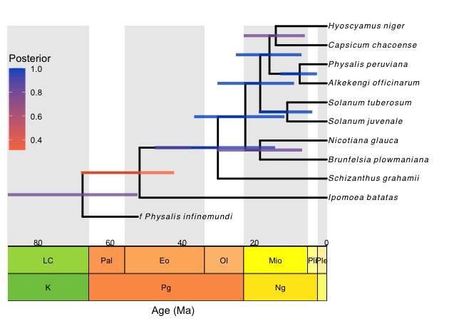

Fig.3. MCC tree resulting from the analysis of this tutorial.

**Important note:** Remember that before making inferences using the trees that result from your analysis, you need to make sure that the **MCMC has converged**. If you are not sure what that means, check out [this tutorial](https://revbayes.github.io/tutorials/convergence/). Furthermore, even if your MCMC has converged, it only means that your results are accurate given your model and your priors. This statement is not meant to discourage you to apply this type of model on your data! Conversely, it is meant to encourage go to keep exploring these methods in [more advanced tutorials](https://revbayes.github.io/tutorials/ted_workflow/) where you will learn how to compare models and assess the adequacy of them for your data.

*Final notes for your thoughts*: For many of the previous notes about what model is better depends on our data. The way to approach these questions is through **model comparison** (*to answer which of competing models is better*) and **model adequacy** (*to answer the question of whether our model assumptions are fair*). In this tutorial we didn’t cover those topics but here are some recommendations: